# DATA 624 | Predictive Analytics

Gabriella Martinez

2022-05-01

# Homework 9: Trees and Rules

## Instructions

In Kuhn and Johnson do problems 8.1, 8.2, 8.3, and 8.7. Please submit a link to your Rpubs and submit the .rmd file as well.

## Packages

```r
library(AppliedPredictiveModeling)
library(dplyr)
library(forecast)
library(ggplot2)
library(tidyr)
library(mice)
library(corrplot)
library(MASS)
library(earth)
library(RANN)
```

## Exercises

### 8.1

**Recreate the simulated data from Exercise 7.2:**

```r
library(mlbench)
set.seed(200)
simulated <- mlbench.friedman1(200, sd = 1)
simulated <- cbind(simulated$x, simulated$y)
simulated <- as.data.frame(simulated)
colnames(simulated)[ncol(simulated)] <- "y"
```

**(a) Fit a random forest model to all of the predictors, then estimate the variable importance scores:**

Variance Importance:

```r
library(randomForest)
library(caret)
model1 <- randomForest(y ~ ., data = simulated, importance = TRUE,
                       ntree = 1000)
rfImp1 <- varImp(model1, scale = FALSE)

order(-rfImp1)
```

```
##  [1]  1  4  2  5  3  6  7 10  9  8
```

```r
rfImp1
```

```
##          Overall
## V1   8.732235404
## V2   6.415369387
## V3   0.763591825
## V4   7.615118809
## V5   2.023524577
## V6   0.165111172
## V7  -0.005961659
## V8  -0.166362581
## V9  -0.095292651
## V10 -0.074944788
```

**Did the random forest model significantly use the uninformative predictors (V6 – V10)?**

Based on the `rfImp1`, uninformative predictors V6 – V10 were not significantly used in the random forest model. Predictors (in order) 1, 4, 2, 5, 3 were significantly used in the random forest model.

**(b) Now add an additional predictor that is highly correlated with one of the informative predictors. For example:**

```r
#creating copy of original data
simulated2 <- simulated

simulated2$duplicate1 <- simulated2$V1 + rnorm(200) * .1
cor(simulated2$duplicate1, simulated2$V1)
```

```
## [1] 0.9460206
```

**Fit another random forest model to these data. Did the importance score for V1 change? What happens when you add another predictor that is also highly correlated with V1?**

Variance Importance:

```r
model2 <- randomForest(y ~ ., data = simulated2, importance = TRUE,
                       ntree = 1000)
rfImp2 <- varImp(model2, scale = FALSE)

order(-rfImp2)
```

```
##  [1]  4  2  1 11  5  3  6 10  9  7  8
```

```r
rfImp2
```

```
##                Overall
## V1          5.69119973
## V2          6.06896061
## V3          0.62970218
## V4          7.04752238
## V5          1.87238438
## V6          0.13569065
## V7         -0.01345645
## V8         -0.04370565
## V9          0.00840438
## V10         0.02894814
## duplicate1  4.28331581
```

Adding a highly correlated shifted the importance score for all predictors. Predictor V1 was demoted from being the most important to third most important along side it’s highly correlated duplicate at fourth place.

**(c) Use the `cforest` function in the `party` package to fit a random forest model using conditional inference trees. The `party` package function `varimp` can calculate predictor importance. The `conditional` argument of that function toggles between the traditional importance measure and the modified version described in Strobl et al. (2007). Do these importances show the same pattern as the traditional random forest model?**

Variance Importance Orders:

```r
library(party)

model3 <- cforest(y ~., data = simulated)

order(-varimp(model3, conditional = FALSE)) #default conditional: FALSE
```

```
##  [1]  1  4  2  5  7  3  9  6 10  8
```

```r
order(-varimp(model3, conditional = TRUE))
```

```
##  [1]  4  1  2  5  3  6  9  8 10  7
```

**(d) Repeat this process with different tree models, such as boosted trees and Cubist. Does the same pattern occur?**

#### Cubist

Variable Importance:

```r
library(Cubist)

simulated_x <- subset(simulated, select = -c(y))

cubist_model <- cubist(x = simulated_x, y = simulated$y, committees = 100)

order(-varImp(cubist_model))
```

```
##  [1]  1  3  4  2  5  6  7  8  9 10
```

#### Boosted Trees

Variable Importance:

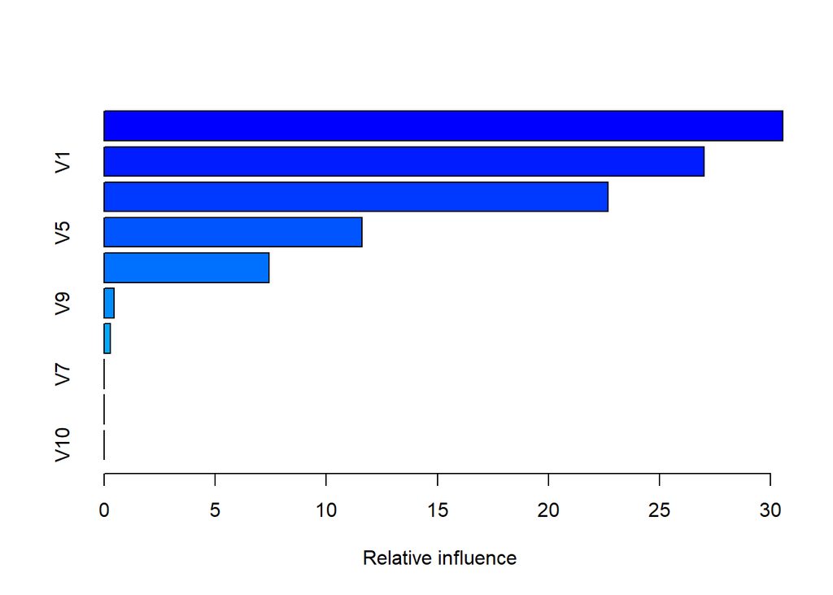

```
##     var    rel.inf
## V4   V4 30.5402762
## V1   V1 26.9937619
## V2   V2 22.6797905
## V5   V5 11.6078356
## V3   V3  7.4358856
## V9   V9  0.4541585
## V6   V6  0.2882918
## V7   V7  0.0000000
## V8   V8  0.0000000
## V10 V10  0.0000000
```

```r
library(gbm)
set.seed(624)

gbm_model <- gbm(y ~., data = simulated, distribution = "gaussian")

summary.gbm(gbm_model)
```

### 8.2

**Use a simulation to show tree bias with different granularities.**

Variance of each predictor:

```r
set.seed(624)
#samples for predictors
low <- sample(0:50, 500, replace = T)
medium <- sample(0:500, 500, replace = T)
high <- sample(0:5000, 500, replace = T)

#response
y <- low + medium + high + rnorm(250)

#check variance of predictors
var(low)
```

```
## [1] 221.9536
```

```r
var(medium)
```

```
## [1] 21752.82
```

```r
var(high)
```

```
## [1] 2016913
```

Variable importance:

```r
sim_data <- data.frame(low, medium, high, y)

diff_gran_model <- randomForest(y ~., data = sim_data, importance = TRUE, ntree = 1000)

varImp(diff_gran_model, scale=FALSE)
```

```
##           Overall
## low     -19996.77
## medium   15806.52
## high   3605673.96
```

### 8.3

**In stochastic gradient boosting the bagging fraction and learning rate will govern the construction of the trees as they are guided by the gradient. Although the optimal values of these parameters should be obtained through the tuning process, it is helpful to understand how the magnitudes of these parameters affect magnitudes of variable importance. Figure 8.24 provides the variable importance plots for boosting using two extreme values for the bagging fraction (0.1 and 0.9) and the learning rate (0.1 and 0.9) for the solubility data. The left-hand plot has both parameters set to 0.1, and the right-hand plot has both set to 0.9:**

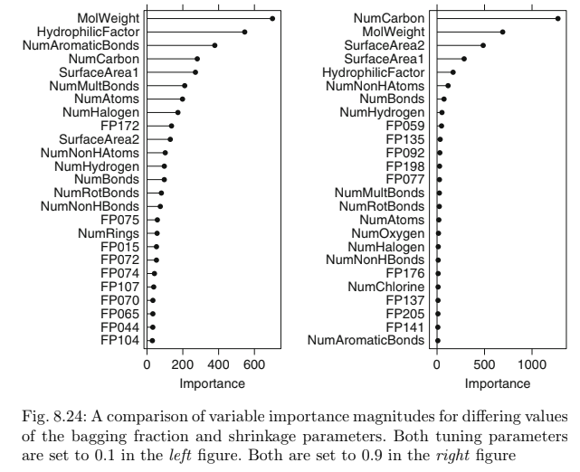

**(a) Why does the model on the right focus its importance on just the first few of predictors, whereas the model on the left spreads importance across more predictors?**

**(b) Which model do you think would be more predictive of other samples?**  
Of the two models, the model on the left (`shrinkage` = 0.1, `bag.fraction` = 0.1) would be more predictive of the samples given the amount of trees it should have in comparison to the model on the right right (`shrinkage` = 0.9, `bag.fraction` = 0.9).

**(c) How would increasing interaction depth affect the slope of predictor importance for either model in Fig. 8.24?**

> “Shrinkage is inversely related to interaction depth (Elith et al. 2008). A model with more complex trees will require fewer total trees. On the other hand, complex trees make the model more vulnerable to overfitting. Therefore, it is recommended that as the tree complexity is increased, the learning rate (shrinkage) is decreased so that the model fits slower and still requires a higher number of trees. Elith et al. (2008) also notes that larger datasets can take better advantage of more complex trees.” [^1] Sec 4.2, pg. 15

Interaction depth, also known as tree size or tree complexity, controls the maximum size of each tree. As noted above, shrinkage is inversely related to interaction depth. The left (`shrinkage` = 0.1, `bag.fraction` = 0.1) might benefit from an increase in interaction depth, while the right might not since the shrinkage parameter is fairly high.

### 8.7

**Refer to Exercises 6.3 and 7.5 which describe a chemical manufacturing process. Use the same data imputation, data splitting, and pre-processing steps as before and train several tree-based models:**

```r
#load data
data(ChemicalManufacturingProcess)

set.seed(624)

#impute, remove near zero values, and remove correlated values using caret
imputed_data <- preProcess(ChemicalManufacturingProcess, method = c("knnImpute","nzv", "corr"))
full_data <- predict(imputed_data, ChemicalManufacturingProcess)

#just realized the below processes can be achieved with preProcess and specifying several methods

#---remove highly correlated vars--- replaced with "corr"
#highly_correlated = findCorrelation(cor(full_data), 0.80)
#full_data = full_data[, -highly_correlated]

#---find low values--- replaced with "nzv"
#low_values <- nearZeroVar(full_data)
#remove low frequency columns using baser df[row,columns]
#chem_data <- full_data[,-low_values]

#split using caret
# index_chem <- createDataPartition(chem_data$Yield , p=.8, list=F)
#
# train_chem <-  chem_data[index_chem,]
# test_chem <- chem_data[-index_chem,]

index_chem <- createDataPartition(full_data$Yield , p=.8, list=F)

train_chem <-  full_data[index_chem,]
test_chem <- full_data[-index_chem,]

train_predictors <- train_chem[-c(1)]
test_predictors <-  test_chem[-c(1)]
```

**(a) Which tree-based regression model gives the optimal resampling and test set performance?**

The Random Forest model provides optimal metrics, with the lowest RMSE of 0.67, and an $R^2$ value of 0.73.

#### Random Forest

```r
set.seed(624)
#fit the model
rf_model <- randomForest(train_predictors, train_chem$Yield, importance = TRUE, ntrees = 1000)
rf_model
```

```
##
## Call:
##  randomForest(x = train_predictors, y = train_chem$Yield, importance = TRUE,      ntrees = 1000)
##                Type of random forest: regression
##                      Number of trees: 500
## No. of variables tried at each split: 15
##
##           Mean of squared residuals: 0.3711346
##                     % Var explained: 59.85
```

```r
rfPred <- predict(rf_model, newdata = test_predictors)
postResample(pred = rfPred, obs = test_chem$Yield)
```

```
##      RMSE  Rsquared       MAE
## 0.6715320 0.7323224 0.4828902
```

#### Boosted Trees

```r
set.seed(624)
gbm_model <- gbm.fit(train_predictors, train_chem$Yield, distribution = "gaussian")
gbm_model
```

```
## A gradient boosted model with gaussian loss function.
## 100 iterations were performed.
## There were 46 predictors of which 7 had non-zero influence.
```

```r
gbmPred <- predict(gbm_model, newdata = test_predictors)
postResample(pred = gbmPred, obs = test_chem$Yield)
```

```
##      RMSE  Rsquared       MAE
## 1.1097582 0.5627084 0.8634997
```

#### Cubist

```r
set.seed(624)
cube_model <- cubist(train_predictors, train_chem$Yield)
cube_model
```

```
##
## Call:
## cubist.default(x = train_predictors, y = train_chem$Yield)
##
## Number of samples: 144
## Number of predictors: 46
##
## Number of committees: 1
## Number of rules: 2
```

```r
cubePred <- predict(cube_model, newdata = test_predictors)
postResample(pred = cubePred, obs = test_chem$Yield)
```

```
##      RMSE  Rsquared       MAE
## 0.6724398 0.6903309 0.5159054
```

**(b) Which predictors are most important in the optimal tree-based regression model? Do either the biological or process variables dominate the list? How do the top 10 important predictors compare to the top 10 predictors from the optimal linear and nonlinear models?**

The predictors dominating the list is `ManufacturingProcess` with 6 in the top ten, and the rest `BiologicalProcess`. This combination is fairly consistent with the importance variables of the non-linear model, not so much the linear model.

Top 10:  
ManufacturingProcess32, BiologicalMaterial06, BiologicalMaterial03, ManufacturingProcess13, ManufacturingProcess36, BiologicalMaterial11, ManufacturingProcess09, BiologicalMaterial08, ManufacturingProcess28, ManufacturingProcess11

```r
head(varImp(rf_model),10)
```

```
##                          Overall
## BiologicalMaterial01    2.166860
## BiologicalMaterial03   11.767253
## BiologicalMaterial05    3.656294
## BiologicalMaterial06   12.943335
## BiologicalMaterial08    8.546350
## BiologicalMaterial09    7.019902
## BiologicalMaterial10    2.524260
## BiologicalMaterial11    9.396847
## ManufacturingProcess01  6.146426
## ManufacturingProcess02  4.739992
```

**(c) Plot the optimal single tree with the distribution of yield in the terminal nodes. Does this view of the data provide additional knowledge about the biological or process predictors and their relationship with yield?**

Yes, this view of the data provides additional knowledge about the biological or process predictors and their relationship with yield. Using the plot we can see the root node is the ManufacturingProcess32 predictor and is then split between two Biological Material predictors. Seven of the ten terminal nodes are predicted by Manufacturing Process variables and remaining three by Biological Material. This suggests that the Manufacturing Process variables are strong predictors of the yield response variable.

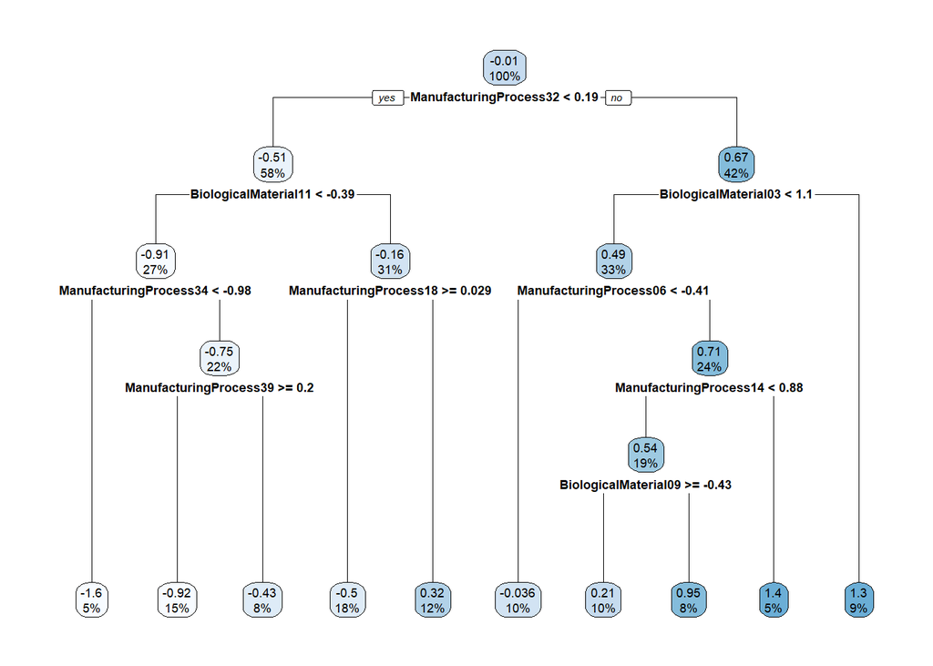

```r
library(rpart)
library(rpart.plot)

#train single tree model
rpart_tree <- rpart(Yield ~., data = train_chem)

#produce tree plot
rpart.plot(rpart_tree)
```

## References

[^1]: https://www.fs.fed.us/rm/pubs_journals/2015/rmrs_2015_freeman_e001.pdf